# Stats506 HW5

Github: https://github.com/KingOliver666/HW-.git

## Problem 1

Use the “nnmaps” data set again. I’d recommend using **ggplot2** for these, but you can do them in base R or **plotly** if you’d prefer.

Part(a):

Produce a graph of the **mean** monthly temperature in **celsius**. Draw a scatter-plot where the x-axis is month and the y-axis is the average monthly temperature in celsius. Add a line connecting the points within each season and color the lines and points by season (same color for lines and points in the same season). Be sure both x-axis and the legend are ordered appropriately, and that all labels/titles are clear and ready for publication (e.g. no variable names).

```r
library(tidyverse)
library(ggplot2)
nnmaps <- read.csv("C:/Users/Lenovo/Downloads/chicago-nmmaps.csv")
# transform the unit of temperature to Celsius
nnmaps$temp_c <- (nnmaps$temp - 32) * 5/9

# Order the date with month
month_order <- c("Jan", "Feb", "Mar", "Apr", "May", "Jun", "Jul", "Aug", "Sep", "Oct", "Nov", "Dec")
nnmaps$month <- factor(nnmaps$month, levels = month_order)

#group our data in month, and then compute the average temperature for each month
temp_month <- nnmaps %>%
  group_by(month, season) %>%
  summarize(average_temp = mean(temp_c), na.rm = TRUE) %>%
  ungroup()
temp_month
```

```
# A tibble: 12 × 4
   month season average_temp na.rm
   <fct> <chr>         <dbl> <lgl>
 1 Jan   Winter        -4.20 TRUE
 2 Feb   Winter         1.21 TRUE
 3 Mar   Winter         4.12 TRUE
 4 Apr   Spring         8.95 TRUE
 5 May   Spring        16.0  TRUE
 6 Jun   Spring        20.6  TRUE
 7 Jul   Summer        23.6  TRUE
 8 Aug   Summer        22.0  TRUE
 9 Sep   Summer        18.5  TRUE
10 Oct   Autumn        12.6  TRUE
11 Nov   Autumn         5.02 TRUE
12 Dec   Autumn        -2.11 TRUE
```

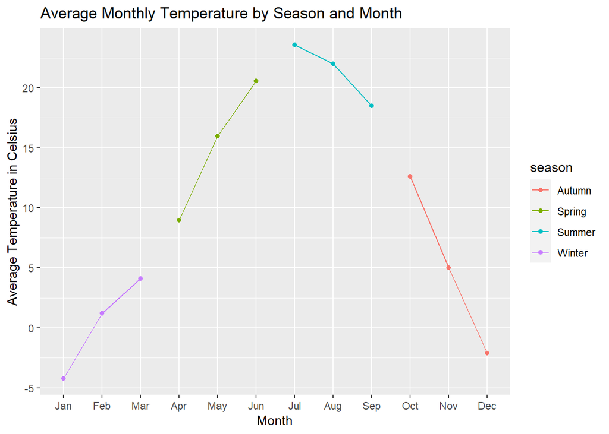

```r
# Start ggplot
ggplot(temp_month, aes(x = month, y = average_temp, group = season, color = season)) +
  geom_point() +
  geom_line() +
  labs(title = "Average Monthly Temperature by Season and Month",
       x = "Month",
       y = "Average Temperature in Celsius")
```

Part(b)

Produce a similar plot with four sets of lines: mean monthly temperature in celsius, mean montly O3, mean monthly PM10, and mean monthly dewpoint. Figure out a way to distinguish between the four lines. Again, make sure the plot is publication-ready (clean and clear labels). Use the plot to answer the following question:

“Which of the four variables seems to have the least seasonal trend?”

I’m not sure if I should put all four lines into a single plot because the meaning of plot does not make any sense for the different unit of “y - variable”, I will first draw 4 different ggplot, and then use basic plot that put 4 lines in a plot.

Plot for O3

```r
temp_O3 <- nnmaps %>%
  group_by(month, season) %>%
  summarize(average_O3 = mean(o3), na.rm = TRUE) %>%
  ungroup()
temp_O3
```

```
# A tibble: 12 × 4
   month season average_O3 na.rm
   <fct> <chr>       <dbl> <lgl>
 1 Jan   Winter      11.4  TRUE
 2 Feb   Winter      16.1  TRUE
 3 Mar   Winter      23.0  TRUE
 4 Apr   Spring      22.2  TRUE
 5 May   Spring      25.6  TRUE
 6 Jun   Spring      27.9  TRUE
 7 Jul   Summer      28.3  TRUE
 8 Aug   Summer      23.0  TRUE
 9 Sep   Summer      20.2  TRUE
10 Oct   Autumn      13.3  TRUE
11 Nov   Autumn      10.4  TRUE
12 Dec   Autumn       9.32 TRUE
```

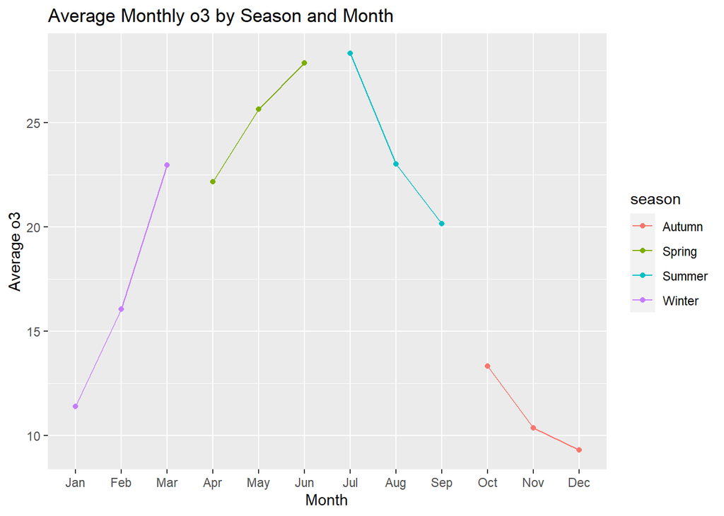

```r
# Start ggplot
ggplot(temp_O3, aes(x = month, y = average_O3, group = season, color = season)) +
  geom_point() +
  geom_line() +
  labs(title = "Average Monthly o3 by Season and Month",
       x = "Month",
       y = "Average o3")
```

Plot for PM10

```r
temp_pm10 <- nnmaps[!is.na(nnmaps$pm10), ]%>%
  group_by(month, season) %>%
  summarize(average_pm10 = mean(pm10), na.rm = TRUE) %>%
  ungroup()
temp_pm10
```

```
# A tibble: 12 × 4
   month season average_pm10 na.rm
   <fct> <chr>         <dbl> <lgl>
 1 Jan   Winter         27.2 TRUE
 2 Feb   Winter         27.7 TRUE
 3 Mar   Winter         26.5 TRUE
 4 Apr   Spring         30.8 TRUE
 5 May   Spring         36.6 TRUE
 6 Jun   Spring         35.3 TRUE
 7 Jul   Summer         36.7 TRUE
 8 Aug   Summer         32.9 TRUE
 9 Sep   Summer         36.1 TRUE
10 Oct   Autumn         38.9 TRUE
11 Nov   Autumn         30.0 TRUE
12 Dec   Autumn         26.1 TRUE
```

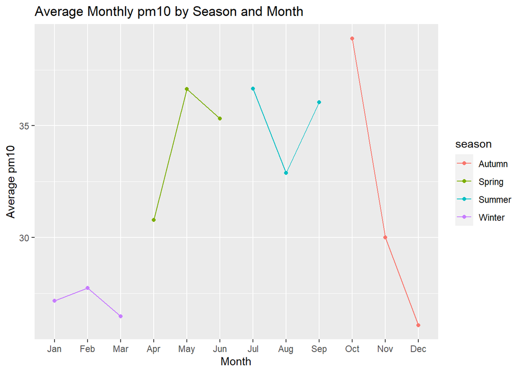

```r
# Start ggplot
ggplot(temp_pm10, aes(x = month, y = average_pm10, group = season, color = season)) +
  geom_point() +
  geom_line() +
  labs(title = "Average Monthly pm10 by Season and Month",
       x = "Month",
       y = "Average pm10")
```

Plot for dewpoint:

```r
temp_dew <- nnmaps %>%
  group_by(month, season) %>%
  summarize(average_dew = mean(dewpoint), na.rm = TRUE) %>%
  ungroup()
temp_dew
```

```
# A tibble: 12 × 4
   month season average_dew na.rm
   <fct> <chr>        <dbl> <lgl>
 1 Jan   Winter        19.4 TRUE
 2 Feb   Winter        27.6 TRUE
 3 Mar   Winter        29.3 TRUE
 4 Apr   Spring        35.8 TRUE
 5 May   Spring        48.8 TRUE
 6 Jun   Spring        58.3 TRUE
 7 Jul   Summer        62.8 TRUE
 8 Aug   Summer        62.3 TRUE
 9 Sep   Summer        54.0 TRUE
10 Oct   Autumn        43.5 TRUE
11 Nov   Autumn        32.0 TRUE
12 Dec   Autumn        21.9 TRUE
```

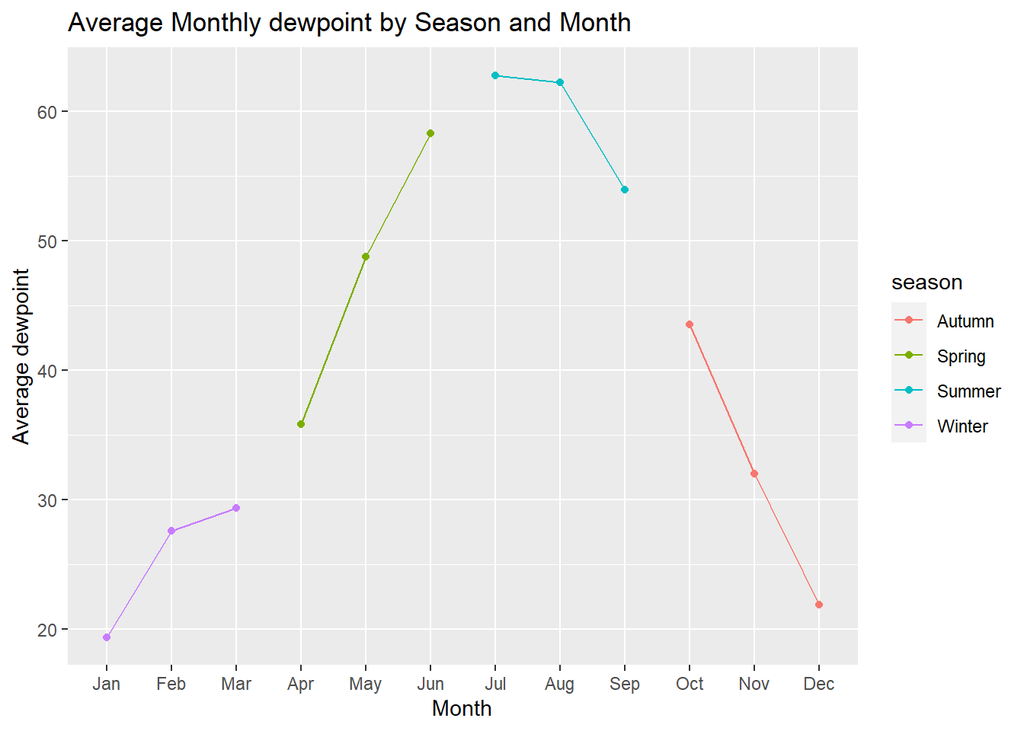

```r
# Start ggplot
ggplot(temp_dew, aes(x = month, y = average_dew, group = season, color = season)) +
  geom_point() +
  geom_line() +
  labs(title = "Average Monthly dewpoint by Season and Month",
       x = "Month",
       y = "Average dewpoint")
```

Answer: after looking as 4 different plots, it seem that the variable of “PM10” have the least seasonal trend.

The below is the basic plot

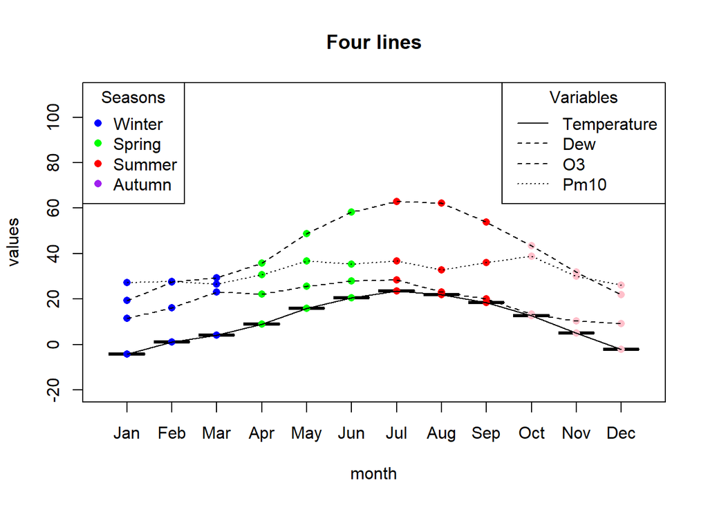

```r
plot(temp_month$month, temp_month$average_temp, xlab = "month", ylab = "values", main = "Four lines", ylim = c(-20, 110))


#Plot points for average temperature vs month
points(temp_month$month[temp_month$season == "Winter"], temp_month$average_temp[temp_month$season == "Winter"], col = "blue", pch = 16)
points(temp_month$month[temp_month$season == "Spring"], temp_month$average_temp[temp_month$season == "Spring"], col = "green", pch = 16)
points(temp_month$month[temp_month$season == "Summer"], temp_month$average_temp[temp_month$season == "Summer"], col = "red", pch = 16)
points(temp_month$month[temp_month$season == "Autumn"], temp_month$average_temp[temp_month$season == "Autumn"], col = "pink", pch = 16)

#Plot points for average dew vs month
points(temp_dew$month[temp_dew$season == "Winter"], temp_dew$average_dew[temp_dew$season == "Winter"], col = "blue", pch = 16)
points(temp_dew$month[temp_dew$season == "Spring"], temp_dew$average_dew[temp_dew$season == "Spring"], col = "green", pch = 16)
points(temp_dew$month[temp_dew$season == "Summer"], temp_dew$average_dew[temp_dew$season == "Summer"], col = "red", pch = 16)
points(temp_dew$month[temp_dew$season == "Autumn"], temp_dew$average_dew[temp_dew$season == "Autumn"], col = "pink", pch = 16)

#Plot points for average O3 vs month
points(temp_O3$month[temp_O3$season == "Winter"], temp_O3$average_O3[temp_O3$season == "Winter"], col = "blue", pch = 16)
points(temp_O3$month[temp_O3$season == "Spring"], temp_O3$average_O3[temp_O3$season == "Spring"], col = "green", pch = 16)
points(temp_O3$month[temp_O3$season == "Summer"], temp_O3$average_O3[temp_O3$season == "Summer"], col = "red", pch = 16)
points(temp_O3$month[temp_O3$season == "Autumn"], temp_O3$average_O3[temp_O3$season == "Autumn"], col = "pink", pch = 16)

#Plot points for average pm10
points(temp_pm10$month[temp_pm10$season == "Winter"], temp_pm10$average_pm10[temp_pm10$season == "Winter"], col = "blue", pch = 16)
points(temp_pm10$month[temp_pm10$season == "Spring"], temp_pm10$average_pm10[temp_pm10$season == "Spring"], col = "green", pch = 16)
points(temp_pm10$month[temp_pm10$season == "Summer"], temp_pm10$average_pm10[temp_pm10$season == "Summer"], col = "red", pch = 16)
points(temp_pm10$month[temp_pm10$season == "Autumn"], temp_pm10$average_pm10[temp_pm10$season == "Autumn"], col = "pink", pch = 16)

#add lines to each variable
lines(temp_month$month, temp_month$average_temp, lty = 1)
lines(temp_dew$month, temp_dew$average_dew,  lty = 20)
lines(temp_O3$month, temp_O3$average_O3,  lty = 8)
lines(temp_pm10$month, temp_pm10$average_pm10,  lty = 15)

#add legend
legend("topleft", legend = c("Winter", "Spring", "Summer", "Autumn"),
       col = c("blue", "green", "red", "purple"),
       pch = c(16, 16, 16, 16),
       title = "Seasons")

legend("topright", legend = c("Temperature", "Dew", "O3", "Pm10"),
       lty = c(1, 20, 8, 15),
       title = "Variables")
```

## Problem 2

Create a class to represent a polynomial expression (such as $7x^3-3x+2$)) called `poly`. Do this using S4.

1. For the `poly` class, define the following:
   - A constructor
   - A validator
   - A `show` method
   - Addition and substraction

```r
# The input should be a vector of coefficient that the length of vector is the (degree of polynonial + 1). Suppose our polynomial is x^3 + x + 1, then the coefficient vector would be (1, 0, 1, 1), and the degree of the polynomial is 4 - 1 = 3
setClass("Mpoly",
         slots = c(coef = "numeric", degree = "character"))



make_poly <- function(coef_1, degree_1){
  return(new("Mpoly", coef = coef_1, degree = degree_1))
}

setValidity("Mpoly", function(object){
  if (!is.numeric(object@coef)){
    stop("Coefficient should be a number")
  }
  if (is.na(as.numeric(object@degree))){
    stop("Invalid degree")
  }
  if (length(object@coef) != as.numeric(object@degree) + 1){
    stop("this is a wrong polynomial")
  }
})
```

```
Class "Mpoly" [in ".GlobalEnv"]

Slots:

Name:       coef    degree
Class:   numeric character
```

```r
setGeneric("deg",
           function(object){
             standardGeneric("deg")
           })
```

```
[1] "deg"
```

```r
setMethod("deg", "Mpoly",
          function(object){
            return(slot(object, "degree"))
          })


#This code intend to display our polynomial, that first build a vector with the same length(n) of coefficient, and store (x^(n-1), x^(n-2), ... x^(0)), then use "paste" and "cat" to construct polynomial like ax^n + bx^(n-1)...+ cx^0
setMethod("show", "Mpoly",
          function(object) {
            validObject(object)
            n <- length(object@coef)
            power_strings <- character(n)
            for (i in 1:n) {
              power_strings[i] <- if (i == n) {
                paste(object@coef[i])
              } else {
                paste(object@coef[i], "x^", n - i, sep = "")
              }
            }
            polynomial_string <- paste(power_strings, collapse = " + ")
            cat("Polynomial expression:\n", polynomial_string, "\n")
          })

getMethod("+")
```

```
function (e1, e2)  .Primitive("+")
```

```r
#This code intend to define the "+" operation
setMethod("+", signature(e1 = "Mpoly",
                         e2 = "Mpoly"),
          function(e1, e2){
            # Here we check if two polynomials have the same degree, if not, we will add some zero terms to the shorter one so that two polynomial have the same length of vector,and so we can add two vectors
            if (length(e1@coef) != length(e2@coef)){
              zeros <- abs(length(e1@coef) - length(e2@coef))
              if (length(e1@coef) > length(e2@coef)){
                e2 <- new("Mpoly", coef = c(rep(0, zeros),e2@coef),
                                            degree =
                            as.character(as.numeric(e2@degree)+zeros))
              }
              else{
                e1 <- new("Mpoly", coef = c(rep(0, zeros), e1@coef),
                                            degree =
                            as.character(as.numeric(e1@degree)+zeros))
              }
            }

            #Here if two polynomials are the same, we will return polynomial with constant 0
            if (sum(e1@coef + e2@coef == rep(0, length(e1@coef)))
                == length(e1@coef)){
              e3 <- new("Mpoly", coef = 0, degree = "0")
              return(e3)
            }

            #Here we will return our final polynomial
            raw_coef <- e1@coef + e2@coef
            first_non_zero <- which(raw_coef != 0)[1]
            new_coef <- raw_coef[first_non_zero : length(raw_coef)]
            e3 <- new("Mpoly", coef = new_coef,
                      degree = as.character(length(new_coef) - 1))
            return(e3)
          })


getMethod("-")
```

```
function (e1, e2)  .Primitive("-")
```

```r
#The idea of this code is very similar the "addition" one,
setMethod("-", signature(e1 = "Mpoly",
                         e2 = "Mpoly"),
          function(e1, e2){
            if (length(e1@coef) != length(e2@coef)){
              zeros <- abs(length(e1@coef) - length(e2@coef))
              if (length(e1@coef) > length(e2@coef)){
                e2 <- new("Mpoly", coef = c(rep(0, zeros),e2@coef),
                                            degree =
                            as.character(as.numeric(e2@degree)+zeros))
              }
              else{
                e1 <- new("Mpoly", coef = c(rep(0, zeros), e1@coef),
                                            degree =
                            as.character(as.numeric(e1@degree)+zeros))
              }
            }


            if (sum(e1@coef - e2@coef == rep(0, length(e1@coef)))
                == length(e1@coef)){
              e3 <- new("Mpoly", coef = 0, degree = "0")
              return(e3)
            }


            raw_coef <- e1@coef - e2@coef
            first_non_zero <- which(raw_coef != 0)[1]
            new_coef <- raw_coef[first_non_zero : length(raw_coef)]
            e3 <- new("Mpoly", coef = new_coef,
                      degree = as.character(length(new_coef) - 1))
            return(e3)
          })
```

b: Use your poly class to run the following code

```r
p1 <- make_poly(c(3, 0, 2), degree = "2")
p2 <- make_poly(c(7, -2, -1, 17), degree = "3")
p1
```

```
Polynomial expression:
 3x^2 + 0x^1 + 2
```

```r
p2
```

```
Polynomial expression:
 7x^3 + -2x^2 + -1x^1 + 17
```

```r
p1 + p2
```

```
Polynomial expression:
 7x^3 + 1x^2 + -1x^1 + 19
```

```r
p1 - p2
```

```
Polynomial expression:
 -7x^3 + 5x^2 + 1x^1 + -15
```

## Problem 3

Install and load the package [**nycflights13**](https://cran.r-project.org/package=nycflights13).

1. Generate a table (which can just be a nicely printed tibble) reporting the mean and median departure delay per airport. Generate a second table (which again can be a nicely printed tibble) reporting the mean and median arrival delay per airport. Exclude any destination with under 10 flights. Do this exclusion through code, not manually.

   Additionally,
   - Order both tables in descending mean delay.
   - Both tables should use the airport *names* not the airport *codes*.
   - Both tables should print all rows.

```r
library(data.table)
library(nycflights13)

##This is the code the report mean delay per airport
flights_table <- as.data.table(flights)
airports_table <- as.data.table(airports)


flights_group <- flights_table[, .(mean_delay = mean(dep_delay, na.rm = TRUE),
                                   med_delay = median(dep_delay, na.rm = TRUE),
                                   numflights = .N), by = origin]

flights_filtered <- flights_group[numflights >= 10]

setnames(flights_filtered, "origin", "faa")

Joined_flights_delay <- merge(flights_filtered, airports_table, by = "faa")

flights_delay <- Joined_flights_delay[, .(name, mean_delay, med_delay)]

flights_delay <- flights_delay[order(-mean_delay)]

flights_delay
```

```
                  name mean_delay med_delay
1: Newark Liberty Intl   15.10795        -1
2: John F Kennedy Intl   12.11216        -1
3:          La Guardia   10.34688        -3
```

```r
## This is the code to report arrival delay
flights_a <- flights_table[, .(mean_delay = mean(arr_delay, na.rm = TRUE),
                                   med_delay = median(arr_delay, na.rm = TRUE),
                                   numflights = .N), by = dest]

flights_filtered_a <- flights_a[numflights >= 10]

setnames(flights_filtered_a, "dest", "faa")

Joined_flights_arrival <- merge(flights_filtered_a, airports_table, by = "faa" , all.x = TRUE)

flights_arrival <- Joined_flights_arrival[, .(name, mean_delay, med_delay)]

flights_arrival <- flights_arrival[order(-mean_delay)]

flights_arrival
```

```
                          name mean_delay med_delay
  1:     Columbia Metropolitan  41.764151      28.0
  2:                Tulsa Intl  33.659864      14.0
  3:         Will Rogers World  30.619048      16.0
  4:      Jackson Hole Airport  28.095238      15.0
  5:             Mc Ghee Tyson  24.069204       2.0
 ---
 98:       Seattle Tacoma Intl  -1.099099     -11.0
 99:             Honolulu Intl  -1.365193      -7.0
100:                      <NA>  -3.835907      -9.0
101: John Wayne Arpt Orange Co  -7.868227     -11.0
102:         Palm Springs Intl -12.722222     -13.5
```

2. How many flights did the aircraft model with the fastest average speed take? Produce a tibble with 1 row, and entires for the model, average speed (in MPH) and number of flights.

```r
# This is the code that produce one row and the model with highest MPH and number of flights
plane_table <- as.data.table(planes)
flights_speed <- merge(flights_table, plane_table, by = "tailnum", all.x = TRUE)

flights_speed[, time := air_time / 60]
flights_speed[, mph := distance / time]

flights_speed_sum <- flights_speed[, .(average_mph = mean(mph, na.rm = TRUE),
                                       num_flights = .N),
                                   by = model]

flights_speed_sum <- flights_speed_sum[order(-average_mph)]

flights_speed_sum[1]
```

```
     model average_mph num_flights
1: 777-222    482.6254           4
```